# DisegnaNormale.R

Ottavia

2025-10-01

```r
############################################################
############################################################
# Distribuzione di densità Normale
# Integrali su intervalli di quantili
############################################################
############################################################


# Grafico generale #########################################
```

Disegna distribzione normale

Restituisce il grafico della distribuzione normale (Densità)

@param limIX Limite inferiore del supporto della distribuzione @param limSX Limite superiore del supporto della distribuzione @param media Media della distribuzione @param ds Deviazione standard @param quantX Quantili della distribuzione che si vogliono visualizzare

@returns plot

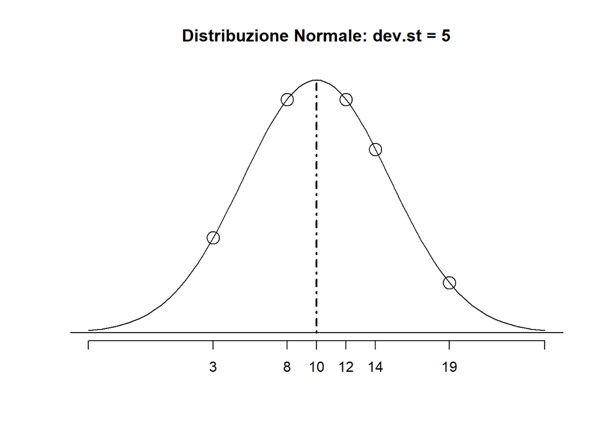

```r
disegnaNorm <- function(limIX,limSX,media,ds,quantX) {

  curve(dnorm(x,media,ds),limIX,limSX,axes=F,xlab="",ylab="",main=paste("Distribuzione Normale: dev.st = ",ds, sep = ""))

  abline(h=0)

  axis(1,c(limIX,media,quantX,limSX),c("",media,quantX,""))

  points(quantX,dnorm(quantX,media,ds),cex=2)
  points(c(media,media),c(0,dnorm(media,media,ds)),type="l",lty=4,lwd=2)

}
Media <- 10
Ds <- 5
limInfX <- qnorm(0.001,Media,Ds)
limSupX <- qnorm(0.999,Media,Ds)
X <- c(3,8,12,19,14)
disegnaNorm(limInfX,limSupX,Media,Ds,X)
```

```r
disegnaNorm(limInfX,limSupX,Media,Ds,X)
```

[output not shown]

Disegna distribuzione normale cumulata

Resituisce il grafico della distribuzione normale (cumulata)

@param limIX Limite inferiore del supporto della distribuzione @param limSX Limite superiore del supporto della distribuzione @param media Media della distribuzione @param ds Deviazione standard @param quantX Quantili della distribuzione che si vogliono visualizzare

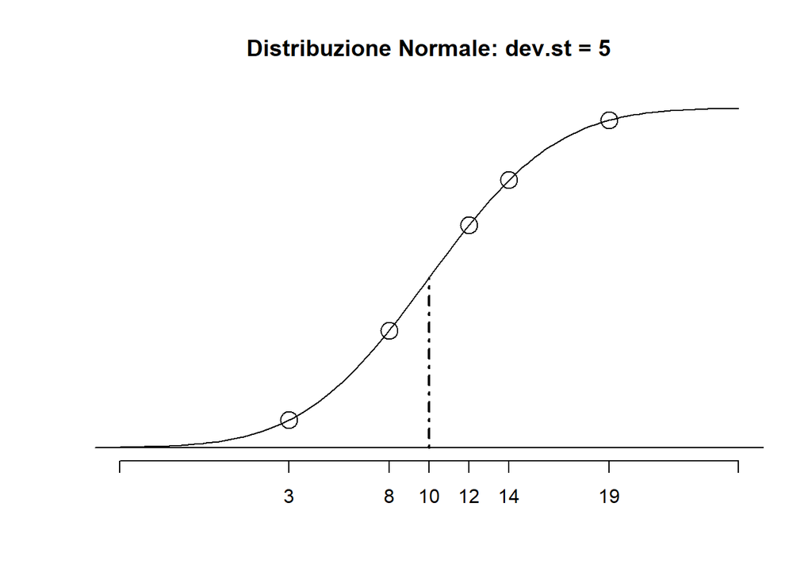

```r
disegnaNormC <- function(limIX,limSX,media,ds,quantX) {

  curve(pnorm(x,media,ds),limIX,limSX,axes=F,xlab="",ylab="",main=paste("Distribuzione Normale: dev.st = ",ds, sep = ""))

  abline(h=0)

  axis(1,c(limIX,media,quantX,limSX),c("",media,quantX,""))

  points(quantX,pnorm(quantX,media,ds),cex=2)
  points(c(media,media),c(0,pnorm(media,media,ds)),type="l",lty=4,lwd=2)

}

Media <- 10
Ds <- 5
limInfX <- qnorm(0.001,Media,Ds)
limSupX <- qnorm(0.999,Media,Ds)
X <- c(3,8,12,19,14)
disegnaNormC(limInfX,limSupX,Media,Ds,X)
```

Integrale parte destra

Area sottesa alla curva dal punto definito nell’argomento quantX fino a più infinito

@param limIX Limite inferiore del supporto della distribuzione @param limSX Limite superiore del supporto della distribuzione @param media Media della distribuzione @param ds Deviazione standard @param quantX Quantile della distribuzione per cui si vuole calcolare l’area fino a più infinito

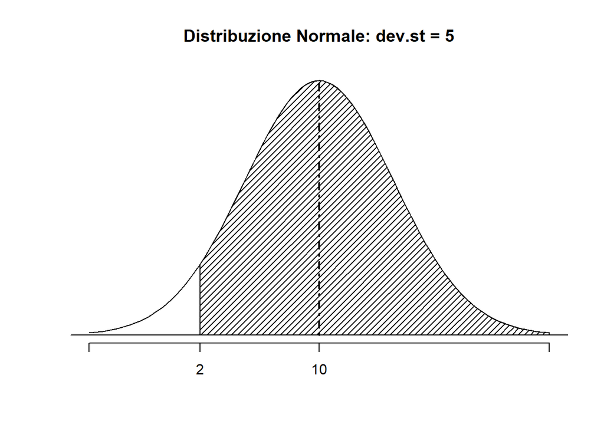

```r
disegnaNormDX <- function(limIX,limSX,media,ds,quantX) {

  curve(dnorm(x,media,ds),limIX,limSX,axes=F,xlab="",ylab="",main=paste("Distribuzione Normale: dev.st = ",ds, sep = ""))

  abline(h=0)

  axis(1,c(limIX,media,quantX,limSX),c("",media,quantX,""))

  vals <- seq(quantX,limSX,length=100)
  x <- c(quantX,vals,limSX,quantX)
  y <- c(0,dnorm(vals,media,ds),0,0)
  polygon(x,y,density=20,angle=45)
  points(c(media,media),c(0,dnorm(media,media,ds)),type="l",lty=4,lwd=2)

}

Media <- 10
Ds <- 5
limInfX <- qnorm(0.001,Media,Ds)
limSupX <- qnorm(0.999,Media,Ds)
X <- c(3,8,12,19,14)
quantileX1 <- 2
quantileX2 <- 8
disegnaNormDX(limInfX,limSupX,Media,Ds,quantileX1)
```

Integrale parte sinistra

Area sottesa alla curva da meno infinito fino al punto definito nell’argomento quantX

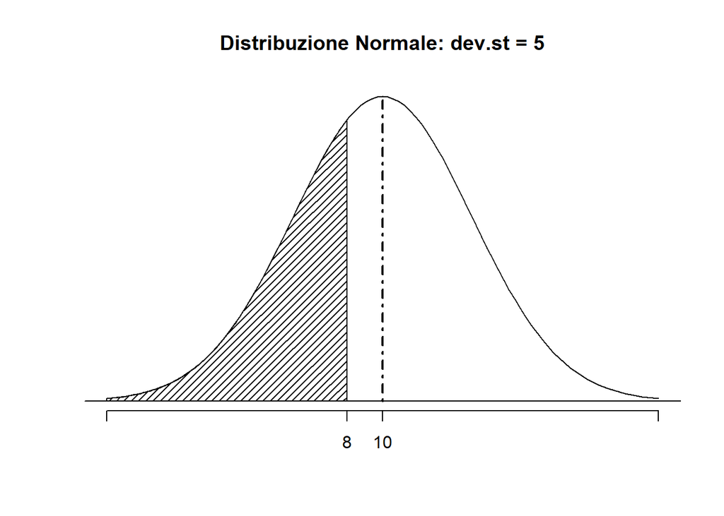

```r
disegnaNormSX <- function(limIX,limSX,media,ds,quantX) {

  curve(dnorm(x,media,ds),limIX,limSX,axes=F,xlab="",ylab="",main=paste("Distribuzione Normale: dev.st = ",ds, sep = ""))

  abline(h=0)

  axis(1,c(limIX,media,quantX,limSX),c("",media,quantX,""))

  vals <- seq(limIX,quantX,length=100)
  x <- c(limIX,vals,quantX,limIX)
  y <- c(0,dnorm(vals,media,ds),0,0)
  polygon(x,y,density=20,angle=45)
  points(c(media,media),c(0,dnorm(media,media,ds)),type="l",lty=4,lwd=2)

}
Media <- 10
Ds <- 5
limInfX <- qnorm(0.001,Media,Ds)
limSupX <- qnorm(0.999,Media,Ds)
X <- c(3,8,12,19,14)
quantileX1 <- 2
quantileX2 <- 8
disegnaNormSX(limInfX,limSupX,Media,Ds,quantileX2)
```

Integrale parte esterna

Area sottesa alla curva tra -infinito e il punto definito in quantX1 e area sottesa alla curva tra quantX2 e +infinito

@param limIX Limite inferiore del supporto della distribuzione @param limSX Limite superiore del supporto della distribuzione @param media Media della distribuzione @param ds Deviazione standard @param quantX1 Quantile della distribuzione (-infinito, quantX1] @param quantX2 Quantile della distribuzione [quantX2, +infinito)

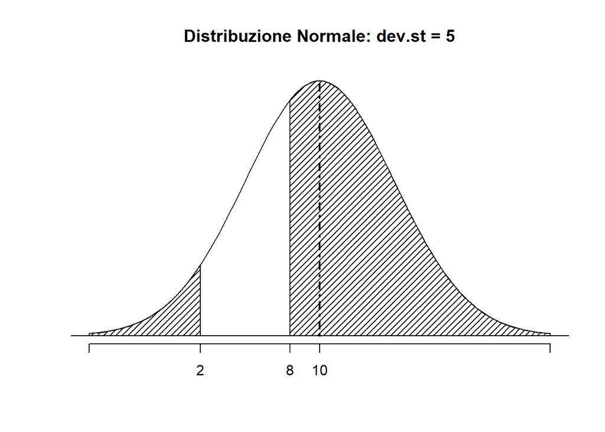

```r
disegnaNormEst <- function(limIX,limSX,media,ds,quantX1,quantX2) {

  curve(dnorm(x,media,ds),limIX,limSX,axes=F,xlab="",ylab="",main=paste("Distribuzione Normale: dev.st = ",ds, sep = ""))

  abline(h=0)

  axis(1,c(limIX,media,quantX1,quantX2,limSX),c("",media,quantX1,quantX2,""))

  vals <- seq(limIX,quantX1,length=100)
  x <- c(limIX,vals,quantX1,limIX)
  y <- c(0,dnorm(vals,media,ds),0,0)
  polygon(x,y,density=20,angle=45)

  vals <- seq(quantX2,limSX,length=100)
  x <- c(quantX2,vals,limSX,quantX2)
  y <- c(0,dnorm(vals,media,ds),0,0)
  polygon(x,y,density=20,angle=45)

  points(c(media,media),c(0,dnorm(media,media,ds)),type="l",lty=4,lwd=2)

}

Media <- 10
Ds <- 5
limInfX <- qnorm(0.001,Media,Ds)
limSupX <- qnorm(0.999,Media,Ds)
X <- c(3,8,12,19,14)
quantileX1 <- 2
quantileX2 <- 8
disegnaNormEst(limInfX,limSupX,Media,Ds,quantileX1,quantileX2)
```

Integrale parte Interna

Area sottesa alla curva tra quantX1 e quantX2

[figure not shown]

```r
disegnaNormInt <- function(limIX,limSX,media,ds,quantX1,quantX2) {

  curve(dnorm(x,media,ds),limIX,limSX,axes=F,xlab="",ylab="",main=paste("Distribuzione Normale: dev.st = ",ds, sep = ""))

  abline(h=0)

  axis(1,c(limIX,media,quantX1,quantX2,limSX),c("",media,quantX1,quantX2,""))

  vals <- seq(quantX1,quantX2,length=100)
  x <- c(quantX1,vals,quantX2,quantX1)
  y <- c(0,dnorm(vals,media,ds),0,0)
  polygon(x,y,density=20,angle=45)

  points(c(media,media),c(0,dnorm(media,media,ds)),type="l",lty=4,lwd=2)

}

Media <- 10
Ds <- 5
limInfX <- qnorm(0.001,Media,Ds)
limSupX <- qnorm(0.999,Media,Ds)
X <- c(3,8,12,19,14)
quantileX1 <- 2
quantileX2 <- 8
disegnaNormEst(limInfX,limSupX,Media,Ds,quantileX1,quantileX2)
```